| title: “Climate Model vs Station Observation Comparisons” |
| --- |
| output: |
| pdf_document: default |
| html_notebook: default |

This script processes annual LOCA and GHCN temperature and rainfall.

The climate model output comes from the USGS [LOCA](http://loca.ucsd.edu) Downscaled Analyses from the CMIP5 climate model runs from 27 models. (There were a total of 32 models used for these analyses but we are only using the model runs that include maximum/miniumum temperature, and precipitation.)

**Table for Available LOCA CMIP5 Point Stations**

| CMIP5 Models | CMIP5 Models | CMIP5 Models |
| --- | --- | --- |
| ACCESS1.0_r1i1p1 | ACCESS1.3_r1i1p1 | CCSM4_r6i1p1 |
| CESM1.BGC_r1i1p1 | CESM1.CAM5_r1i1p1 | CMCC.CMS_r1i1p1 |
| CMCC.CM_r1i1p1 | CNRM.CM5_r1i1p1 | CSIRO.Mk3.6.0_r1i1p1 |
| CanESM2_r1i1p1 | FGOALS.g2_r1i1p1 | GFDL.CM3_r1i1p1 |
| GFDL.ESM2G_r1i1p1 | GFDL.ESM2M_r1i1p1 | HadGEM2.AO_r1i1p1 |
| HadGEM2.CC_r1i1p1 | HadGEM2.ES_r1i1p1 | IPSL.CM5A.LR_r1i1p1 |
| IPSL.CM5A.MR_r1i1p1 | MIROC.ESM.CHEM_r1i1p1 | MIROC.ESM_r1i1p1 |
| MIROC5_r1i1p1 | MPI.ESM.LR_r1i1p1 | MPI.ESM.MR_r1i1p1 |
| MRI.CGCM3_r1i1p1 | NorESM1.M_r1i1p1 | bcc.csm1.1.m_r1i1p1 |

The result is an *ensemble* of 27 independant virtual earths for our simulation period from 1950 to 2099.

The simulations further diverge at 2006 where our model runs separate into two scenarios.

- **RCP 4.5**: A simulation targeting a total amount of 4.5 W m<sup>2</sup> addition greenhouse forcing
- **RCP 8.5**: A simulation targeting a total amount of 8.5 W m<sup>2</sup> addition greenhouse forcing

Together, we use these two future cases to reprsent upper and lower bounds of likely expected future climates depending on current and projected greenhouse gas emissions. (The “RPC” stands for [“Representative Pathway Concentration”](https://link.springer.com/article/10.1007/s10584-011-0148-z))

```r
# R Libraries
  library(ncdf4)
  library(ncdf4.helpers)
  library(reshape2)
  library(PCICt)
  library(lubridate)
  library(ggplot2)
  library(quantreg)
  library(climdex.pcic)
  library(seas)
  library(dplyr)
  library(ClimClass)
  library(geosphere)
```

For this worksheet, we have taken the larger US LOCA model outputs and have extracted time series from select stations in South Dakota.

**Table for Available LOCA CMIP5 Point Stations**

| Name | ICAO Code for LOCA Data | GHCN Station Recommended Match |
| --- | --- | --- |
| Sioux Falls, SD | KFSD | GHCND-USW00014944__SIOUX_FALLS_FOSS_FIELD_SD |
| Aberdeen, SD | KABR | GHCND-USW00014929__ABERDEEN_REGIONAL_AIRPORT_SD |
| Huron, SD | KHON | GHCND-USW00014936__HURON_REGIONAL_AIRPORT_SD |
| Pierre, SD | KPIR | GHCND-USW00024025__PIERRE_REGIONAL_AIRPORT_SD |
| Vermillion, SD | KVMR | GHCND-USC00398622__VERMILLION_2_SE_SD |
| Faith, SD | KD07 | GHCND-USC00392852__FAITH_SD |
| Pine Ridge, SD | KIEN | GHCND-USC00396612__PINE_RIDGE_SD |
| Mobridge, SD | KMBG | GHCND-USW00094052__MOBRIDGE_MUNICIPAL_AIRPORT_SD |
| Winner, SD | KICR | GHCND-USC00399367__WINNER_SD |
| Mitchell, SD | KHME | GHCND-USC00395671__MITCHELL_2_N_SD |
| Custer, SD | KCUT | GHCND-USC00392087__CUSTER_SD |
| Spearfish, SD | KSPF | GHCND-USC00397882__SPEARFISH_SD |
| Watertown, SD | KATY | GHCND-USW00014946__WATERTOWN_REGIONAL_AIRPORT_SD |
| Sisseton, SD | K8D3 | GHCND-USC00397742__SISSETON_SD |
| Buffalo, SD | K9D2 | GHCND-USC00391114__BUFFALO_SD |
| Bison, SD | K6V5 | GHCND-USC00390701__BISON_SD |
| Lemmon, SD | KLEM | GHCND-USC00394864__LEMMON_SD |
| Rapid City, SD | KRAP | GHCND-USW00024090__RAPID_CITY_REGIONAL_AIRPORT_SD |
| Brookings, SD | KBKX | GHCND-USC00391076__BROOKINGS_2_NE_SD |
| Phillip, SD | KPHP | GHCND-USW00024024__PHILIP_AIRPORT_SD |
| Tyndall, SD | SD61 | GHCND-USC00398472__TYNDALL_SD |
| Yankton, SD | KYKN | GHCND-USW00094911__YANKTON_SD |

The LOCA data is archived by the point’s 4-letter International Civil Aviation Organization (ICAO) [station codes](https://en.wikipedia.org/wiki/ICAO_airport_code) for the nearest airfield.

Observation data is taken from [Global Historical Climatology Network (GHCN)](https://www.ncdc.noaa.gov/data-access/land-based-station-data/land-based-datasets/global-historical-climatology-network-ghcn)

```r
  ## selected ICAO station code goes below
  station_abbreviation = "KHON"
  ## selected GHCN station identifier goes here
  GHCN_file_name = "GHCND-USW00014936__HURON_REGIONAL_AIRPORT_SD"

  ## Manually Enter User-Prefered Station Name

  station_name = "Huron, SD"
  ghcn_station = "Huron, SD"
```

Climate Scenarios are not designed to determine “how many inches of partly sunny you’ll need to shovel off your doorstep on 15 January 2052”. Rather they are a collection of statistics, such as the average and standard deviation (the spread).

Typically we use a period of about 30 years to extract it.

For some of the statitics we will explore later, in this example, we’ll use a baseline period (historical period) of 1961-1990. This particular period has been used since early climate assessments and we retain its use for continuity.

The projection (forecast) period can be selected for any period.

```r
 # Selecting two 30-year periods to compare
 # historical (baseline) period
 period_length       = 30
 period_1_start_year = 1961
 period_1_end_year   = period_1_start_year + period_length - 1

 # projection period
 period_2_start_year = 2031
 period_2_end_year   = period_2_start_year + period_length - 1
```

We keep our climate data on a server at SD Mines. This data is available [online](http://kyrill.ias.sdsmt.edu:8080/thredds) and can be accessed by software designed to read weather and cliamte data.

We are extracting data for daily, monthly and annual fields

```r
  # Cracking Open the LOCA Point Data Rdata Files (Monthly)
  date_interval_lab = "Monthly"

  date_interval_files = toupper(date_interval_lab)
  URL_LOCA_Directory = "http://kyrill.ias.sdsmt.edu:8080/thredds/fileServer/LOCA_POINT/"

  URL_LOCA_File = paste(URL_LOCA_Directory,
                       "LOCA_",
                       date_interval_files,
                       "_",
                       station_abbreviation,
                       ".Rdata",
                       sep = "")

  load( file = url(description = URL_LOCA_File) )

  colnames(loca_all)[ 8] = "Min_Temperature"
  colnames(loca_all)[ 9] = "Max_Temperature"
  colnames(loca_all)[10] = "Avg_Temperature"
  colnames(loca_all)[11] = "Total_Precip"

  loca_mon = loca_all

  loca_mon$Ensemble = as.character(loca_mon$Ensemble)
  loca_mon$Scenario = as.character(loca_mon$Scenario)

  ####################

  loca_annual_time = aggregate(formula = Time ~ year(Time) + Ensemble + Scenario,
                                         data    = loca_mon,
                                         FUN     = mean)

  date_string = paste(year(loca_annual_time$Time),
                      "-01-01 12:00:00 UTC",
                      sep="")
  loca_year = data.frame(Time     = as.POSIXct(date_string),
                         Ensemble = loca_annual_time$Ensemble,
                         Scenario = loca_annual_time$Scenario)

  loca_year$Ensemble = as.character(loca_year$Ensemble)
  loca_year$Scenario = as.character(loca_year$Scenario)

  loca_year$Min_Temperature = aggregate(formula   = Min_Temperature ~ year(Time) + Ensemble + Scenario,
                                        data      = loca_mon,
                                        FUN       = mean,
                                        na.action = na.pass)
  loca_year$Min_Temperature = loca_year$Min_Temperature$Min_Temperature

  loca_year$Max_Temperature = aggregate(formula   = Max_Temperature ~ year(Time) + Ensemble + Scenario,
                                       data      = loca_mon,
                                       FUN       = mean,
                                       na.action = na.pass)
  loca_year$Max_Temperature = loca_year$Max_Temperature$Max_Temperature
  loca_year$Avg_Temperature = aggregate(formula   = Avg_Temperature ~ year(Time) + Ensemble + Scenario,
                                       data      = loca_mon,
                                       FUN       = mean,
                                       na.action = na.pass)

  loca_year$Avg_Temperature = loca_year$Avg_Temperature$Avg_Temperature
  loca_year$Total_Precip    = aggregate(formula   = Total_Precip ~ year(Time) + Ensemble + Scenario,
                                       data      = loca_mon,
                                       FUN       = sum,
                                       na.action = na.pass)

  loca_year$Total_Precip    = loca_year$Total_Precip$Total_Precip



  loca_year$Station    = as.character(loca_mon[1,]$Station)
  loca_year$Elevation  = as.numeric(loca_mon[1,]$Elevation)
  loca_year$Latitude   = as.numeric(loca_mon[1,]$Latitude)
  loca_year$Longitude  = as.numeric(loca_mon[1,]$Longitude)

  loca_year = loca_year[ ,colnames(loca_mon)]


  ####################

  remove(loca_all)
  remove(URL_LOCA_Directory)
  remove(URL_LOCA_File)
  remove(date_interval_files)
  remove(loca_annual_time)
  remove(date_string)
```

```r
  # Cracking Open the LOCA Point Data Rdata Files (Daily)
  date_interval_lab = "Daily"

  date_interval_files = toupper(date_interval_lab)
  URL_LOCA_Directory = "http://kyrill.ias.sdsmt.edu:8080/thredds/fileServer/LOCA_POINT/"

  URL_LOCA_File = paste(URL_LOCA_Directory,
                       "LOCA_",
                       date_interval_files,
                       "_",
                       station_abbreviation,
                       ".Rdata",
                       sep = "")

  load( file = url(description = URL_LOCA_File) )

  colnames(loca_all)[ 8] = "Min_Temperature"
  colnames(loca_all)[ 9] = "Max_Temperature"
  colnames(loca_all)[10] = "Avg_Temperature"
  colnames(loca_all)[11] = "Total_Precip"

  loca_daily = loca_all

  loca_daily$Ensemble = as.character(loca_daily$Ensemble)
  loca_daily$Scenario = as.character(loca_daily$Scenario)

  Scenario = unique(as.character(loca_daily$Scenario))
    Ensemble = unique(as.character(loca_daily$Ensemble))
  ####################

  remove(loca_all)
  remove(URL_LOCA_Directory)
  remove(URL_LOCA_File)
  remove(date_interval_files)
```

The GHCN data can also be searched at the following website using either names or searchable map [Here](http://kyrill.ias.sdsmt.edu:8080/repository/entry/show?entryid=ef83a85b-cf31-4274-821f-02761953a3cf).

omit the .nc from the *GHCN_file_name* variable

```r
  # Cracking Open the GHCN Point Data Files

  GHCN_Base_URL = "http://kyrill.ias.sdsmt.edu:8080/thredds/dodsC/GHCN_POINT_DATA/"


  GHCN_URL = paste(GHCN_Base_URL,
                   GHCN_file_name,
                   ".nc",
                   sep = "")

  nc_ghcn = nc_open(filename=GHCN_URL)

  nc_ghcn_variables = nc.get.variable.list(f         = nc_ghcn,
                                           min.dims =        1)


  ghcn_time = as.POSIXct(x  = nc.get.time.series(f = nc_ghcn,
                                                 v = "maximum_air_temperature"),
                         tz = "UTC")

  ghcn_maximum_air_temperature = ncvar_get(nc    =  nc_ghcn,
                                           varid = "maximum_air_temperature")

  ghcn_minimum_air_temperature = ncvar_get(nc    =  nc_ghcn,
                                           varid = "minimum_air_temperature")
  if (any(nc_ghcn_variables == "mean_air_temperature" )) {
    ghcn_mean_air_temperature    = ncvar_get(nc    =  nc_ghcn,
                                             varid = "mean_air_temperature")
  } else {
    ghcn_mean_air_temperature   = ghcn_minimum_air_temperature
    ghcn_mean_air_temperature[] = NA
  }

  ghcn_precipitation_amount    = ncvar_get(nc    =  nc_ghcn,
                                           varid = "precipitation_amount")

  ghcn_station_name            = ncvar_get(nc    =  nc_ghcn,
                                           varid = "station_name")

  ghcn_latitude                = ncvar_get(nc    =  nc_ghcn,
                                           varid = "latitude")
  ghcn_longitude               = ncvar_get(nc    =  nc_ghcn,
                                           varid = "longitude")
  ghcn_altitude                = ncvar_get(nc    =  nc_ghcn,
                                           varid = "altitude")

  nc_close(nc_ghcn)

  remove(GHCN_Base_URL)
  remove(GHCN_file_name)
  remove(GHCN_URL)
  remove(nc_ghcn)

  ghcn_daily = data.frame(Time            = ghcn_time,
                          Max_Temperature = ghcn_maximum_air_temperature,
                          Min_Temperature = ghcn_minimum_air_temperature,
                          Avg_Temperature = ghcn_mean_air_temperature,
                          Total_Precip    = ghcn_precipitation_amount,
                          Year            = year(ghcn_time),
                          Month           = month(ghcn_time))

  ghcn_daily = subset(ghcn_daily[ (ghcn_daily$Year > 1949), ])
  ghcn_daily[is.na(ghcn_daily$Avg_Temperature),]$Avg_Temperature =
             (ghcn_daily[is.na(ghcn_daily$Avg_Temperature),]$Max_Temperature  +
              ghcn_daily[is.na(ghcn_daily$Avg_Temperature),]$Min_Temperature) /2
  ghcn_daily[is.na(ghcn_daily$Max_Temperature),]$Avg_Temperature <- NA
  ghcn_daily[is.na(ghcn_daily$Min_Temperature),]$Avg_Temperature <- NA

  ## Aggregate (aveage and sum) daily obsrvations to both monthly and annual periods
  ghcn_monthly_time = aggregate(formula = Time ~ Month + Year ,
                                          data    = ghcn_daily,
                                          FUN     = mean)

  date_string = paste(ghcn_monthly_time$Year,
                      "-",
                      sprintf("%0.2i", ghcn_monthly_time$Month) ,
                      "-01 12:00:00 UTC",
                      sep="")
  ghcn_mon = data.frame(Time = as.POSIXct(date_string) )


  ghcn_mon$Min_Temperature = aggregate(formula   = Min_Temperature ~ Month + Year,
                                       data      = ghcn_daily,
                                       FUN       = mean,
                                       na.action = na.pass)
  ghcn_mon$Min_Temperature = ghcn_mon$Min_Temperature$Min_Temperature

  ghcn_mon$Max_Temperature = aggregate(formula   = Max_Temperature ~ Month + Year,
                                       data      = ghcn_daily,
                                       FUN       = mean,
                                       na.action = na.pass)
  ghcn_mon$Max_Temperature = ghcn_mon$Max_Temperature$Max_Temperature
  ghcn_mon$Avg_Temperature = aggregate(formula   = Avg_Temperature ~ Month + Year,
                                       data      = ghcn_daily,
                                       FUN       = mean,
                                       na.action = na.pass)

  ghcn_mon$Avg_Temperature = ghcn_mon$Avg_Temperature$Avg_Temperature
  ghcn_mon$Total_Precip    = aggregate(formula   = Total_Precip ~ Month + Year,
                                       data      = ghcn_daily,
                                       FUN       = sum,
                                       na.action = na.pass)

  ghcn_mon$Total_Precip    = ghcn_mon$Total_Precip$Total_Precip

  ghcn_mon$Station    = ghcn_station_name
  ghcn_mon$Elevation  = ghcn_altitude
  ghcn_mon$Latitude   = ghcn_latitude
  ghcn_mon$Longitude  = ghcn_longitude
  ghcn_mon$Ensemble   = "GHCN Network"
  ghcn_mon$Scenario   = "Observations"

  ghcn_mon = ghcn_mon[,colnames(loca_mon)]
  ###################################
  ## Aggregate (aveage and sum) daily obsrvations to both monthly and annual periods
  ghcn_annual_time = aggregate(formula = Time ~ Year,
                                         data    = ghcn_daily,
                                         FUN     = mean)

  date_string = paste(ghcn_annual_time$Year,
                      "-01-01 12:00:00 UTC",
                      sep="")
  ghcn_year = data.frame(Time = as.POSIXct(date_string) )


  ghcn_year$Min_Temperature = aggregate(formula   = Min_Temperature ~ Year,
                                        data      = ghcn_daily,
                                        FUN       = mean,
                                        na.action = na.pass)
  ghcn_year$Min_Temperature = ghcn_year$Min_Temperature$Min_Temperature

  ghcn_year$Max_Temperature = aggregate(formula   = Max_Temperature ~ Year,
                                       data      = ghcn_daily,
                                       FUN       = mean,
                                       na.action = na.pass)
  ghcn_year$Max_Temperature = ghcn_year$Max_Temperature$Max_Temperature
  ghcn_year$Avg_Temperature = aggregate(formula   = Avg_Temperature ~ Year,
                                       data      = ghcn_daily,
                                       FUN       = mean,
                                       na.action = na.pass)

  ghcn_year$Avg_Temperature = ghcn_year$Avg_Temperature$Avg_Temperature
  ghcn_year$Total_Precip    = aggregate(formula   = Total_Precip ~ Year,
                                       data      = ghcn_daily,
                                       FUN       = sum,
                                       na.action = na.pass)

  ghcn_year$Total_Precip    = ghcn_year$Total_Precip$Total_Precip

  ghcn_year$Station    = ghcn_station_name
  ghcn_year$Elevation  = ghcn_altitude
  ghcn_year$Latitude   = ghcn_latitude
  ghcn_year$Longitude  = ghcn_longitude
  ghcn_year$Ensemble   = "GHCN Network"
  ghcn_year$Scenario   = "Observations"

  if (month(max(ghcn_mon$Time)) != 12) {
     ghcn_year[ year(ghcn_year$Time)   ==  year(max(ghcn_mon$Time))   ,]$Total_Precip    = NA
     ghcn_year[ year(ghcn_year$Time)   ==  year(max(ghcn_mon$Time))   ,]$Min_Temperature = NA
     ghcn_year[ year(ghcn_year$Time)   ==  year(max(ghcn_mon$Time))   ,]$Max_Temperature = NA
     ghcn_year[ year(ghcn_year$Time)   ==  year(max(ghcn_mon$Time))   ,]$Avg_Temperature = NA
  }
  ghcn_year = ghcn_year[,colnames(loca_mon)]

  ghcn_daily$Station    = ghcn_station_name
  ghcn_daily$Elevation  = ghcn_altitude
  ghcn_daily$Latitude   = ghcn_latitude
  ghcn_daily$Longitude  = ghcn_longitude
  ghcn_daily$Ensemble   = "GHCN Network"
  ghcn_daily$Scenario   = "Observations"

  ghcn_daily = ghcn_daily[,colnames(loca_mon)]

  ###################################


  remove(date_string)
  remove(ghcn_time)
  remove(ghcn_monthly_time)
  remove(ghcn_annual_time)
  remove(ghcn_maximum_air_temperature)
  remove(ghcn_minimum_air_temperature)
  remove(ghcn_mean_air_temperature)
  remove(ghcn_precipitation_amount)
  remove(ghcn_altitude)
  remove(ghcn_latitude)
  remove(ghcn_longitude)
```

```r
# Merge both the observations and model output
all_daily = rbind(ghcn_daily,  loca_daily)
all_month = rbind(  ghcn_mon,    loca_mon)
all_year  = rbind( ghcn_year,   loca_year)
all_year_scenario_factor = factor(x      = all_year$Scenario)
all_year_scenario_factor = factor(x      = all_year_scenario_factor,
                                  levels = levels(all_year_scenario_factor)[c(2, 3, 1)])
all_year$Scenario = all_year_scenario_factor
all_month_scenario_factor = factor(x      = all_month$Scenario)
all_month_scenario_factor = factor(x      = all_month_scenario_factor,
                                  levels = levels(all_month_scenario_factor)[c(2, 3, 1)])
all_month$Scenario = all_month_scenario_factor
all_daily_scenario_factor = factor(x      = all_daily$Scenario)
all_daily_scenario_factor = factor(x      = all_daily_scenario_factor,
                                   levels = levels(x = all_daily_scenario_factor)[c(2, 3, 1)])
all_daily$Scenario = all_daily_scenario_factor
###################
all_year$Case = as.character(NA)
all_year[((all_year$Scenario == "Observations") &
         ((year(all_year$Time) >= period_1_start_year) &
          (year(all_year$Time) <= period_1_end_year))),]$Case = paste(period_1_start_year,
                                                                       "-",
                                                                       period_1_end_year,
                                                                       " GHCN",
                                                                       sep = "")
all_year[((all_year$Scenario != "Observations") &
         ((year(all_year$Time) >= period_1_start_year) &
          (year(all_year$Time) <= period_1_end_year))),]$Case = paste(period_1_start_year,
                                                                       "-",
                                                                       period_1_end_year,
                                                                       " LOCA",
                                                                       sep = "")
all_year[((all_year$Scenario == "RCP 4.5") &
         ((year(all_year$Time) >= period_2_start_year) &
          (year(all_year$Time) <= period_2_end_year))),]$Case = paste(period_2_start_year,
                                                                      "-",
                                                                      period_2_end_year,
                                                                      " RCP 4.5",
                                                                      sep = "")
all_year[((all_year$Scenario == "RCP 8.5") &
         ((year(all_year$Time) >= period_2_start_year) &
          (year(all_year$Time) <= period_2_end_year))),]$Case = paste(period_2_start_year,
                                                                      "-",
                                                                      period_2_end_year,
                                                                      " RCP 8.5",
                                                                      sep = "")
###################
all_month$Case = as.character(NA)
all_month[((all_month$Scenario == "Observations") &
         ((year(all_month$Time) >= period_1_start_year) &
          (year(all_month$Time) <= period_1_end_year))),]$Case = paste(period_1_start_year,
                                                                       "-",
                                                                       period_1_end_year,
                                                                       " GHCN",
                                                                       sep = "")
all_month[((all_month$Scenario != "Observations") &
         ((year(all_month$Time) >= period_1_start_year) &
          (year(all_month$Time) <= period_1_end_year))),]$Case = paste(period_1_start_year,
                                                                       "-",
                                                                       period_1_end_year,
                                                                       " LOCA",
                                                                       sep = "")
all_month[((all_month$Scenario == "RCP 4.5") &
         ((year(all_month$Time) >= period_2_start_year) &
          (year(all_month$Time) <= period_2_end_year))),]$Case = paste(period_2_start_year,
                                                                      "-",
                                                                      period_2_end_year,
                                                                      " RCP 4.5",
                                                                      sep = "")
all_month[((all_month$Scenario == "RCP 8.5") &
         ((year(all_month$Time) >= period_2_start_year) &
          (year(all_month$Time) <= period_2_end_year))),]$Case = paste(period_2_start_year,
                                                                      "-",
                                                                      period_2_end_year,
                                                                      " RCP 8.5",
                                                                      sep = "")
###################
all_daily$Case = as.character(NA)
all_daily[((all_daily$Scenario == "Observations") &
         ((year(all_daily$Time) >= period_1_start_year) &
          (year(all_daily$Time) <= period_1_end_year))),]$Case = paste(period_1_start_year,
                                                                       "-",
                                                                       period_1_end_year,
                                                                       " GHCN",
                                                                       sep = "")
all_daily[((all_daily$Scenario != "Observations") &
         ((year(all_daily$Time) >= period_1_start_year) &
          (year(all_daily$Time) <= period_1_end_year))),]$Case = paste(period_1_start_year,
                                                                       "-",
                                                                       period_1_end_year,
                                                                       " LOCA",
                                                                       sep = "")
all_daily[((all_daily$Scenario == "RCP 4.5") &
         ((year(all_daily$Time) >= period_2_start_year) &
          (year(all_daily$Time) <= period_2_end_year))),]$Case = paste(period_2_start_year,
                                                                      "-",
                                                                      period_2_end_year,
                                                                      " RCP 4.5",
                                                                      sep = "")
all_daily[((all_daily$Scenario == "RCP 8.5") &
         ((year(all_daily$Time) >= period_2_start_year) &
          (year(all_daily$Time) <= period_2_end_year))),]$Case = paste(period_2_start_year,
                                                                      "-",
                                                                      period_2_end_year,
                                                                      " RCP 8.5",
                                                                      sep = "")
all_year_case_factor = factor(x      = all_year$Case)
all_year_case_factor = factor(x      = all_year_case_factor,
                                  levels = levels(all_year_case_factor)[c(2, 3, 4, 1)])
all_year$Case = all_year_case_factor
all_mon_case_factor = factor(x      = all_month$Case)
all_mon_case_factor = factor(x      = all_mon_case_factor,
                                  levels = levels(all_mon_case_factor)[c(2, 3, 4, 1)])
all_month$Case = all_mon_case_factor
all_daily_case_factor = factor(x      = all_daily$Case)
all_daily_case_factor = factor(x      = all_daily_case_factor,
                                  levels = levels(all_daily_case_factor)[c(2, 3, 4, 1)])
all_daily$Case = all_daily_case_factor
##########
all_year$Alpha  = 0
all_year[ (all_year$Ensemble=="GHCN Network"), ]$Alpha  = 1
all_month$Alpha = 0
all_month[(all_month$Ensemble=="GHCN Network"), ]$Alpha = 1
all_daily$Alpha = 0
all_daily[(all_daily$Ensemble=="GHCN Network"), ]$Alpha = 1
remove(all_year_scenario_factor)
remove(all_daily_scenario_factor)
remove(all_month_scenario_factor)
```

For our annual data we also can add data capturing upper and lower bounds using percentiles and related stats.

This will declutter some of our graphs below.

```r
################### Statitics Across Ensembles by Time & Scenario ###############################

   #################### Means

  avg.mean = aggregate(formula   = cbind(Min_Temperature,
                                         Avg_Temperature,
                                         Max_Temperature,
                                         Total_Precip) ~ Scenario + Time,
                       data      = all_year,
                       FUN       = mean,
                       na.action = na.pass)

  avg.mean$Aggregate_Stat = "Mean"


   #################### Stdev

  sd.stdev = aggregate(formula   = cbind(Min_Temperature,
                                         Avg_Temperature,
                                         Max_Temperature,
                                         Total_Precip) ~ Scenario + Time,
                       data      = loca_year,
                       FUN       = sd,
                       na.action = na.pass)

  sd.stdev$Aggregate_Stat = "StDev"

   #################### Q0
  qtiles.q0 = aggregate(formula   = cbind(Min_Temperature,
                                         Avg_Temperature,
                                         Max_Temperature,
                                         Total_Precip) ~ Scenario + Time,
                       data      = loca_year,
                       FUN       = min,
                       na.rm     = TRUE)

  qtiles.q0$Aggregate_Stat = "Q0"
  qtiles.q1 = aggregate(formula   = cbind(Min_Temperature,
                                         Avg_Temperature,
                                         Max_Temperature,
                                         Total_Precip) ~ Scenario + Time,
                       data      = loca_year,
                       FUN       = quantile, probs = 0.25,
                       na.rm     = TRUE)

  qtiles.q1$Aggregate_Stat = "Q1"
   #################### Q1


  qtiles.q2 = aggregate(formula   = cbind(Min_Temperature,
                                         Avg_Temperature,
                                         Max_Temperature,
                                         Total_Precip) ~ Scenario + Time,
                       data      = loca_year,
                       FUN       = quantile, probs = 0.50,
                       na.rm     = TRUE)

  qtiles.q2$Aggregate_Stat = "Q2"
   #################### Q3


  qtiles.q3 = aggregate(formula   = cbind(Min_Temperature,
                                         Avg_Temperature,
                                         Max_Temperature,
                                         Total_Precip) ~ Scenario + Time,
                        data      = loca_year,
                        FUN       = quantile, probs = 0.75,
                        na.rm     = TRUE)

  qtiles.q3$Aggregate_Stat = "Q3"
   #################### Q4
  qtiles.q4 = aggregate(formula   = cbind(Min_Temperature,
                                         Avg_Temperature,
                                         Max_Temperature,
                                         Total_Precip) ~ Scenario + Time,
                        data      = loca_year,
                        FUN       = max,
                        na.rm     = TRUE)

  qtiles.q4$Aggregate_Stat = "Q4"

  #################### merge and clean

  all_year.stats = rbind(avg.mean,
                         sd.stdev,
                         qtiles.q0,
                         qtiles.q1,
                         qtiles.q2,
                         qtiles.q3,
                         qtiles.q4)
  remove(avg.mean)
  remove(sd.stdev)
  remove(qtiles.q0)
  remove(qtiles.q1)
  remove(qtiles.q2)
  remove(qtiles.q3)
  remove(qtiles.q4)
  all_year.stats$Station   = all_year$Station[1]
  all_year.stats$Longitude = all_year$Longitude[1]
  all_year.stats$Latitude  = all_year$Latitude[1]
  all_year.stats$Elevation = all_year$Elevation[1]

  all_year.stats = all_year.stats[, c(8:11,2,1,7,3:6)]
```

```r
# Processing ETCCDMI Indicies and other metrics

  all_daily$date = all_daily$Time
      ############ Obs #############
      ensemble  = "GHCN Network"
      scenario  = "Observations"
      mysubset = subset(all_daily, Scenario==scenario)
      Time_PCICt = as.PCICt(mysubset$Time, cal="gregorian")


        #### Process ETCCMI Indicies

        ETCCDMI_stat_gh = climdexInput.raw(tmax = mysubset$Max_Temperature,
                                           tmin = mysubset$Min_Temperature,
                                           prec = mysubset$Total_Precip,
                                           tmax.dates = Time_PCICt,
                                           tmin.dates = Time_PCICt,
                                           prec.dates = Time_PCICt,
                                           base.range = c(1961, 1990),
                                           n = 5,
                                           northern.hemisphere = TRUE,
                                           tavg = mysubset$Avg_Temperature,
                                           tavg.dates = Time_PCICt,
                                           temp.qtiles = c(0.1, 0.9),
                                           prec.qtiles = c(0.95, 0.99),
                                           max.missing.days = c(annual = 15,
                                                                monthly = 3),
                                           min.base.data.fraction.present = 0.1)

        #### Process Wetting Rain Interval


        wetting_rain_interval_block = interarrival(x     = mysubset,
                                                   var   = "Total_Precip",
                                                   p.cut = (0.5 * 25.4) ,
                                                   inv   = FALSE)

        wetting_rain_interval_block$Ensemble  = ensemble
        wetting_rain_interval_block$Scenario  = scenario

        attr(wetting_rain_interval_block, "name")       = NULL
        attr(wetting_rain_interval_block, "year.range") = NULL
        attr(wetting_rain_interval_block, "inv")        = NULL
        attr(wetting_rain_interval_block, "p.cut")      = NULL
        #### Clean

        wetting_rain_interval = wetting_rain_interval_block
        remove(mysubset)
        remove(Time_PCICt)

        remove(wetting_rain_interval_block)

  #### RCP 4.5 and RCP 8.5 ###
  for (ensemble in unique(loca_year$Ensemble) ) {


      print(paste("Processing Ensembles for Specific Indicies ",ensemble))

      ############ 4.5 #############

      scenario = "RCP 4.5"



      mysubset = subset(all_daily, (Scenario==scenario) &
                                   (Ensemble==ensemble))


      Time_PCICt = as.PCICt(mysubset$Time, cal="gregorian")


        #### Process ETCCMI Indicies

        ETCCDMI_stat_45 = climdexInput.raw(tmax = mysubset$Max_Temperature,
                                           tmin = mysubset$Min_Temperature,
                                           prec = mysubset$Total_Precip,
                                           tmax.dates = Time_PCICt,
                                           tmin.dates = Time_PCICt,
                                           prec.dates = Time_PCICt,
                                           base.range = c(1961, 1990),
                                           n = 5,
                                           northern.hemisphere = TRUE,
                                           tavg = mysubset$Avg_Temperature,
                                           tavg.dates = Time_PCICt,
                                           temp.qtiles = c(0.1, 0.9),
                                           prec.qtiles = c(0.95, 0.99),
                                           max.missing.days = c(annual = 15,
                                                                monthly = 3),
                                           min.base.data.fraction.present = 0.1)

        #### Process Wetting Rain Interval


        wetting_rain_interval_block = interarrival(x     = mysubset,
                                                   var   = "Total_Precip",
                                                   p.cut = (0.5 * 25.4) ,
                                                   inv   = FALSE)

        wetting_rain_interval_block$Ensemble  = ensemble
        wetting_rain_interval_block$Scenario  = scenario

        attr(wetting_rain_interval_block, "name")       = NULL
        attr(wetting_rain_interval_block, "year.range") = NULL
        attr(wetting_rain_interval_block, "inv")        = NULL
        attr(wetting_rain_interval_block, "p.cut")      = NULL

        wetting_rain_interval = bind_rows(wetting_rain_interval,
                                          wetting_rain_interval_block)

        remove(wetting_rain_interval_block)
        #### Clean


      remove(mysubset)
      remove(Time_PCICt)

      ############ 8.5 #############
      scenario = "RCP 8.5"


      mysubset = subset(all_daily, (Scenario==scenario) &
                                   (Ensemble==ensemble))
      Time_PCICt = as.PCICt(mysubset$Time, cal="gregorian")


        #### Process ETCCMI Indicies

        ETCCDMI_stat_85 = climdexInput.raw(tmax = mysubset$Max_Temperature,
                                           tmin = mysubset$Min_Temperature,
                                           prec = mysubset$Total_Precip,
                                           tmax.dates = Time_PCICt,
                                           tmin.dates = Time_PCICt,
                                           prec.dates = Time_PCICt,
                                           base.range = c(1961, 1990),
                                           n = 5,
                                           northern.hemisphere = TRUE,
                                           tavg = mysubset$Avg_Temperature,
                                           tavg.dates = Time_PCICt,
                                           temp.qtiles = c(0.1, 0.9),
                                           prec.qtiles = c(0.95, 0.99),
                                           max.missing.days = c(annual = 15,
                                                                monthly = 3),
                                           min.base.data.fraction.present = 0.1)

        #### Process Wetting Rain Interval


        wetting_rain_interval_block = interarrival(x     = mysubset,
                                                   var   = "Total_Precip",
                                                   p.cut = (0.5 * 25.4) ,
                                                   inv   = FALSE)

        wetting_rain_interval_block$Ensemble  = ensemble
        wetting_rain_interval_block$Scenario  = scenario

        attr(wetting_rain_interval_block, "name")       = NULL
        attr(wetting_rain_interval_block, "year.range") = NULL
        attr(wetting_rain_interval_block, "inv")        = NULL
        attr(wetting_rain_interval_block, "p.cut")      = NULL

        wetting_rain_interval = bind_rows(wetting_rain_interval,
                                          wetting_rain_interval_block)

        remove(wetting_rain_interval_block)
        #### Clean


      remove(mysubset)
      remove(Time_PCICt)



      ##############################################

  }
```

```
[1] "Processing Ensembles for Specific Indicies  ACCESS1.0_r1i1p1"
[1] "Processing Ensembles for Specific Indicies  ACCESS1.3_r1i1p1"
[1] "Processing Ensembles for Specific Indicies  bcc.csm1.1.m_r1i1p1"
[1] "Processing Ensembles for Specific Indicies  CanESM2_r1i1p1"
[1] "Processing Ensembles for Specific Indicies  CCSM4_r6i1p1"
[1] "Processing Ensembles for Specific Indicies  CESM1.BGC_r1i1p1"
[1] "Processing Ensembles for Specific Indicies  CESM1.CAM5_r1i1p1"
[1] "Processing Ensembles for Specific Indicies  CMCC.CM_r1i1p1"
[1] "Processing Ensembles for Specific Indicies  CMCC.CMS_r1i1p1"
[1] "Processing Ensembles for Specific Indicies  CNRM.CM5_r1i1p1"
[1] "Processing Ensembles for Specific Indicies  CSIRO.Mk3.6.0_r1i1p1"
[1] "Processing Ensembles for Specific Indicies  FGOALS.g2_r1i1p1"
[1] "Processing Ensembles for Specific Indicies  GFDL.CM3_r1i1p1"
[1] "Processing Ensembles for Specific Indicies  GFDL.ESM2G_r1i1p1"
[1] "Processing Ensembles for Specific Indicies  GFDL.ESM2M_r1i1p1"
[1] "Processing Ensembles for Specific Indicies  HadGEM2.AO_r1i1p1"
[1] "Processing Ensembles for Specific Indicies  HadGEM2.CC_r1i1p1"
[1] "Processing Ensembles for Specific Indicies  HadGEM2.ES_r1i1p1"
[1] "Processing Ensembles for Specific Indicies  IPSL.CM5A.LR_r1i1p1"
[1] "Processing Ensembles for Specific Indicies  IPSL.CM5A.MR_r1i1p1"
[1] "Processing Ensembles for Specific Indicies  MIROC.ESM_r1i1p1"
[1] "Processing Ensembles for Specific Indicies  MIROC.ESM.CHEM_r1i1p1"
[1] "Processing Ensembles for Specific Indicies  MIROC5_r1i1p1"
[1] "Processing Ensembles for Specific Indicies  MPI.ESM.LR_r1i1p1"
[1] "Processing Ensembles for Specific Indicies  MPI.ESM.MR_r1i1p1"
[1] "Processing Ensembles for Specific Indicies  MRI.CGCM3_r1i1p1"
[1] "Processing Ensembles for Specific Indicies  NorESM1.M_r1i1p1"
```

```r
  names(wetting_rain_interval)[2] = "Days_Between_Wetting_Rain"
  names(wetting_rain_interval)[3] = "Consecutive_Days_of_Wetting_Rain"


  all_daily = merge(x = all_daily,
        y = wetting_rain_interval,
        by = c("date","Scenario","Ensemble"),
        sort = TRUE)
  remove(wetting_rain_interval)
```

If we look at the observed data and measured output plotted against time (shown here for both average annual temperature, precipitation), we can see that for most of our datasets, observations are contained inside of the envelope of the ensemble “members.”

Also notice that in our area, you can start to see the moderate future case (RCP 4.5) and the more extreme case (RCP 8.5), diverge with respect to temperature.

In the Great Plains, however, the variations in rainfall are less clear. This is one of the concerns of climate change in this region. We may break even (or be a *little* wetter), but the higher temperatures will create higher amounts of evaporation.

```r
# some parts of ggplot2 have not been playing nice with alphas so I am trying to create some custom colours
myalph = 0.4
blue_trans   = rgb(red  =     0.0,
                   blue =     1.0,
                   green =    0.0,
                   alpha =  myalph)
green_trans = rgb(red  =     0.0,
                  blue =     0.0,
                  green =    1.0,
                  alpha = myalph)
red_trans   = rgb(red  =     1.0,
                  blue =     0.0,
                  green =    0.0,
                  alpha = myalph)
myalph = 0.2
blue_clear   = rgb(red  =     0.0,
                   blue =     1.0,
                   green =    0.0,
                   alpha =  myalph)
green_clear = rgb(red  =     0.0,
                  blue =     0.0,
                  green =    1.0,
                  alpha = myalph)
red_clear   = rgb(red  =     1.0,
                  blue =     0.0,
                  green =    0.0,
                  alpha = myalph)
```

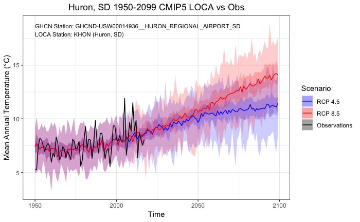

```r
# Plot all the ensembles envelopes.
  # to start we need to take our "long" R format
  #  and for the variable we want to plot, we need
  #  to put it into a 2-d wide format.
  # in this case we want the various stats for our plotted
  #   value to go across the columns.
  # first we isolate the values we want to retain for plotting
  stat_table = subset(x      = all_year.stats,
                      select = c(Time,
                                 Scenario,
                                 Aggregate_Stat,
                                 Avg_Temperature))

  # then we "spread" our statistics column (Aggregate_Stat) across multiple
  #  cols (one column for each unique stat in that column) (that's our *key*)
  #  and distribute the contents of the *value* into the new "2-D" space
  stat_table =  spread(data  = stat_table,       # data frame
                       key   = Aggregate_Stat,   # column that will be "spread" by its unique values
                       value = Avg_Temperature)  # the variable to be distributed over the x-y new space
  ggplot(data = stat_table)  +
    aes(x     = Time,
        y     = Mean,
        color =Scenario,
        fill = Scenario) +

    theme_bw() +
    theme(plot.title = element_text(hjust = 0.5)) +

    scale_color_manual(values = c("blue",
                                 "red",
                                 "black")) +

    geom_ribbon(data    = stat_table,
                mapping = aes(x     = Time,
                              ymin  = Q0,
                              ymax  = Q4,
                              color = Scenario),
                alpha   = 0.2,
                colour  = NA) +

    geom_ribbon(data    = stat_table,
                mapping = aes(x     = Time,
                              ymin  = Q1,
                              ymax  = Q3,
                              color = Scenario),
                alpha   = 0.2,
                colour  = NA) +

    geom_line() +

    scale_fill_manual(values = c("blue",
                                 "red",
                                 "black")) +
    theme_bw() +
    theme(plot.title = element_text(hjust = 0.5)) +
    annotate("text",
             x=min(all_year$Time),
             y=Inf,
             label = paste("\n",
                           "GHCN Station: ",
                           ghcn_station_name,
                           "\n",
                           "LOCA Station: ",
                           station_abbreviation,
                           " (",
                           loca_year[1,]$Station,
                           ")",sep=""),
             size = 3,
             hjust = 0,
             vjust = 1) +
    labs(title = paste(loca_year[,]$Station,
                       " ",
                       min(year(loca_year$Time)),
                       "-",
                       max(year(loca_year$Time)),
                       " CMIP5 LOCA vs Obs",
                       sep = ""),
         y     = paste('Mean Annual Temperature (°C)',
                       sep = "") )
```

```r
  remove(stat_table)
```

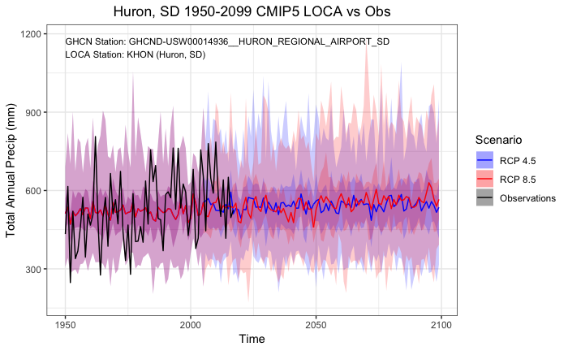

```r
# Plot all the ensembles envelopes.
  # to start we need to take our "long" R format
  #  and for the variable we want to plot, we need
  #  to put it into a 2-d wide format.
  # in this case we want the various stats for our plotted
  #   value to go across the columns.
  # first we isolate the values we want to retain for plotting
  stat_table = subset(x      = all_year.stats,
                      select = c(Time,
                                 Scenario,
                                 Aggregate_Stat,
                                 Total_Precip))

  # then we "spread" our statistics column (Aggregate_Stat) across multiple
  #  cols (one column for each unique stat in that column) (that's our *key*)
  #  and distribute the contents of the *value* into the new "2-D" space
  stat_table =  spread(data  = stat_table,       # data frame
                       key   = Aggregate_Stat,   # column that will be "spread" by its unique values
                       value = Total_Precip)  # the variable to be distributed over the x-y new space
  ggplot(data = stat_table)  +
    aes(x     = Time,
        y     = Mean,
        color = Scenario,
        fill  = Scenario) +

    theme_bw() +
    theme(plot.title = element_text(hjust = 0.5)) +

    scale_color_manual(values = c("blue",
                                 "red",
                                 "black")) +

    geom_ribbon(data    = stat_table,
                mapping = aes(x     = Time,
                              ymin  = Q0,
                              ymax  = Q4,
                              color = Scenario),
                alpha   = 0.2,
                colour  = NA) +

    geom_ribbon(data    = stat_table,
                mapping = aes(x     = Time,
                              ymin  = Q1,
                              ymax  = Q3,
                              color = Scenario),
                alpha   = 0.2,
                colour  = NA) +

    geom_line() +
    scale_fill_manual(values = c("blue",
                                 "red",
                                 "black")) +
    theme_bw() +
    theme(plot.title = element_text(hjust = 0.5)) +
    annotate("text",
             x=min(all_year$Time),
             y=Inf,
             label = paste("\n",
                           "GHCN Station: ",
                           ghcn_station_name,
                           "\n",
                           "LOCA Station: ",
                           station_abbreviation,
                           " (",
                           loca_year[1,]$Station,
                           ")",sep=""),
             size = 3,
             hjust = 0,
             vjust = 1) +
    labs(title = paste(loca_year[,]$Station,
                       " ",
                       min(year(loca_year$Time)),
                       "-",
                       max(year(loca_year$Time)),
                       " CMIP5 LOCA vs Obs",
                       sep = ""),
         y     = paste('Total Annual Precip (mm)',
                       sep = "") )
```

```r
  remove(stat_table)
```

```r
 # Selecting two 30-year periods to compare
 all_year_period_1   = subset(all_year,((year(Time) >= period_1_start_year) &
                                        (year(Time) <= period_1_end_year))   )

 all_year_period_1$Period  = paste(period_1_start_year,
                                   "-",
                                   period_1_end_year,
                                   sep = "")

 all_year_period_2   = subset(all_year,((year(Time) >= period_2_start_year) &
                                        (year(Time) <= period_2_end_year))   )

 all_year_period_2$Period  = paste(period_2_start_year,
                                   "-",
                                   period_2_end_year,
                                   sep = "")
```

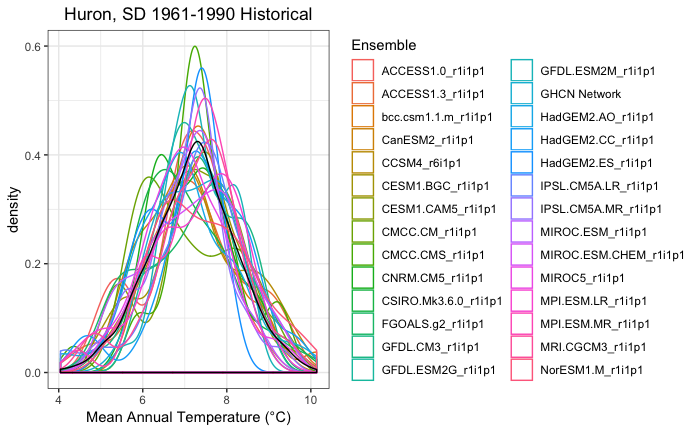

```r
 # Plot all the ensembles for one case
  mysubset = subset(x      = all_year_period_1,
                    select = Scenario!="RCP 8.5")

  ggplot(data=mysubset)  +

    aes(x=Avg_Temperature, color=Ensemble) +

    geom_density() +

    geom_density(data=mysubset, color="black") +

    theme_bw() +
    theme(plot.title = element_text(hjust = 0.5)) +
    labs(title = paste(loca_year[1,]$Station,
                       " ",
                       period_1_start_year,
                       "-",
                       period_1_end_year,
                       " Historical",
                       sep = ""),
         x     = paste('Mean Annual Temperature (°C)',
                       sep = "") )
```

```r
NA
```

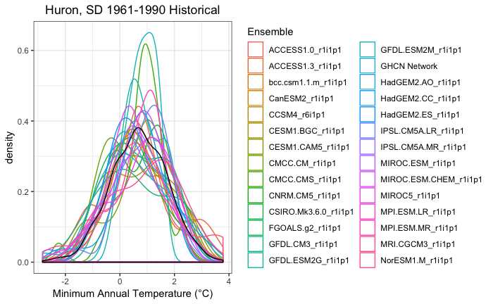

```r
 # Plot all the ensembles for one case
  mysubset = subset(x      = all_year_period_1,
                    subset = Scenario != "RCP 8.5")

  ggplot(data=mysubset)  +

    aes(x=Min_Temperature, color=Ensemble) +

    geom_density() +

    geom_density(data=mysubset, color="black") +

    theme_bw() +
    theme(plot.title = element_text(hjust = 0.5)) +
    labs(title = paste(loca_year[1,]$Station,
                       " ",
                       period_1_start_year,
                       "-",
                       period_1_end_year,
                       " Historical",
                       sep = ""),
         x     = paste('Minimum Annual Temperature (°C)',
                       sep = "") )
```

```r
NA
```

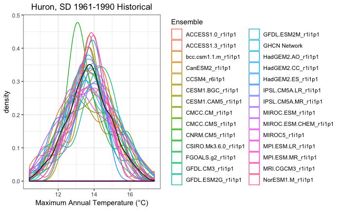

```r
 # Plot all the ensembles for one case
  mysubset = subset(x      = all_year_period_1,
                    subset = Scenario != "RCP 8.5")

  ggplot(data=mysubset)  +

    aes(x=Max_Temperature, color=Ensemble) +

    geom_density() +

    geom_density(data=mysubset,
                 color="black") +

    theme_bw() +
    theme(plot.title = element_text(hjust = 0.5)) +
    labs(title = paste(loca_year[1,]$Station,
                       " ",
                       period_1_start_year,
                       "-",
                       period_1_end_year,
                       " Historical",
                       sep = ""),
         x     = paste('Maximum Annual Temperature (°C)',
                       sep = "") )
```

```r
NA
```

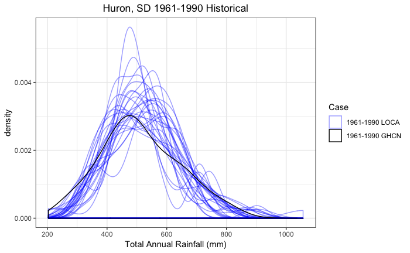

```r
 # Plot all the ensembles for one case
  mysubset = subset(x      = all_year_period_1,
                    subset = Scenario != "RCP 8.5")
  ggplot(data=mysubset)  +

    aes(x     = Total_Precip,
        color = Case,
        line  = Ensemble) +

    geom_density() +

        scale_colour_manual(values=c(blue_trans,"black"))+

    theme_bw() +
    theme(plot.title = element_text(hjust = 0.5)) +
    labs(title = paste(loca_year[1,]$Station,
                       " ",
                       period_1_start_year,
                       "-",
                       period_1_end_year,
                       " Historical",
                       sep = ""),
         x     = paste('Total Annual Rainfall (mm)',
                       sep = "") )
```

```r
NA
```

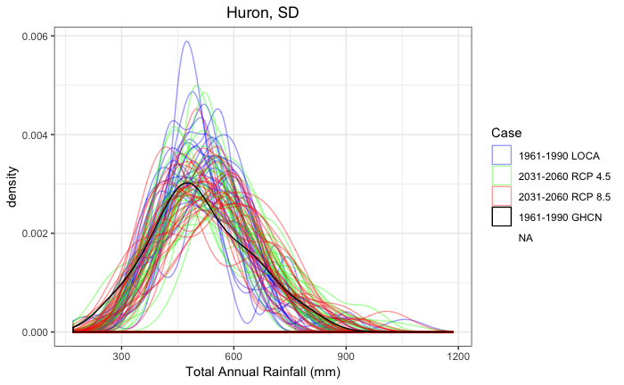

```r
 # Plot all the ensembles for one case
ggplot(data=subset(x      = all_year,
                   select = !is.na(Case) ))  +

    aes(x     = Total_Precip,
        color = Case,
        line  = Ensemble) +

    geom_density() +

    scale_colour_manual(values=c(blue_trans,green_trans,red_trans,"black"))+

    theme_bw() +
    theme(plot.title = element_text(hjust = 0.5)) +
    labs(title = paste(loca_year[1,]$Station,
                       sep = ""),
         x     = paste('Total Annual Rainfall (mm)',
                       sep = "") )
```

```r
NA
```

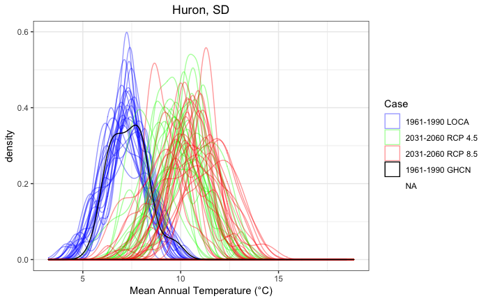

```r
 # Plot all the ensembles for one case
  ggplot(data=subset(x      = all_year,
                   select = !is.na(Case) ))  +

    aes(x     = Avg_Temperature,
        color = Case,
        line  = Ensemble) +

    geom_density() +

    scale_colour_manual(values=c(blue_trans,
                                 green_trans,
                                 red_trans,
                                 "black"))+

    theme_bw() +
    theme(plot.title = element_text(hjust = 0.5)) +
    labs(title = paste(loca_year[1,]$Station,
                       sep = ""),
         x     = paste('Mean Annual Temperature (°C)',
                       sep = "") )
```

```r
NA
```

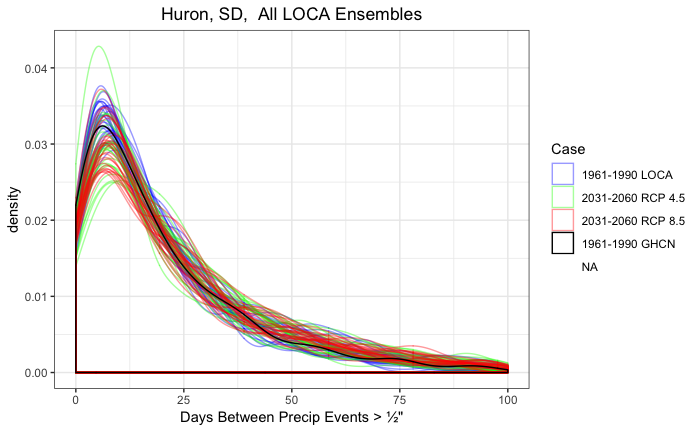

```r
  ggplot(data=subset(x      = all_daily,
                     select = !is.na(Case) ))  +
    aes(x     = Days_Between_Wetting_Rain,
        color = Case,
        line  = Ensemble,
        alpha = Alpha) +
    theme_bw() +
    theme(plot.title = element_text(hjust = 0.5)) +
    geom_density(alpha = 0.2) +
    scale_alpha_continuous(range = c(0.1, 1.0),
                           guide = FALSE)  +

    scale_colour_manual(values=c(blue_trans,
                                 green_trans,
                                 red_trans,
                                 "black"))+

    scale_x_continuous(limits = c(0,100)) +
    labs(title = paste(station_name,
                       ",  ",
                       "All LOCA Ensembles",
                       sep = ""),
         x     = paste('Days Between Precip Events > ½"',
                       sep = ""))
```

```r
NA
```

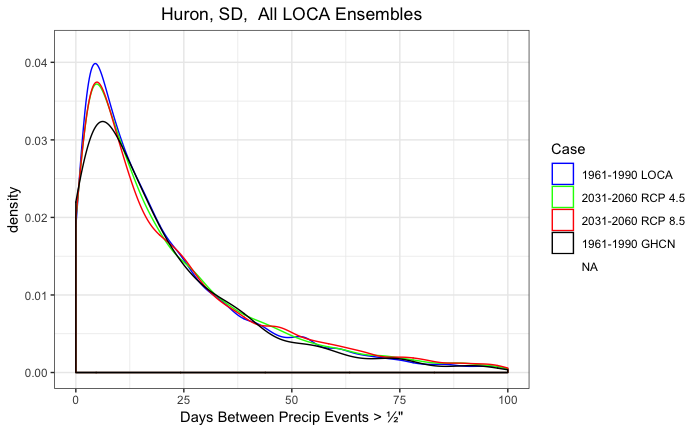

```r
  ggplot(data=subset(x      = all_daily,
                     select = !is.na(Case) ))  +
    aes(x     = Days_Between_Wetting_Rain,
        color = Case,
        alpha = Alpha) +
    theme_bw() +
    theme(plot.title = element_text(hjust = 0.5)) +
    geom_density() +
    scale_alpha_continuous(range = c(0.1, 1.0),
                           guide = FALSE)  +

    scale_colour_manual(values=c("blue","green","red","black"))+
      scale_fill_manual(values=c("blue","green","red","black"))+
    scale_x_continuous(limits = c(0,100)) +
    labs(title = paste(station_name,
                       ",  ",
                       "All LOCA Ensembles",
                       sep = ""),
         x     = paste('Days Between Precip Events > ½"',
                       sep = ""))
```

```r
NA
```